# Serie 1

T.Watrigant

2 Novembre 2017

# Exercices 1.2, 2.1, 2.2 traités en R

# Exercice 1.7 traité à l’ecrit

# Exercice 1.2

Preuve de la formule de densité de probabilité pour :

- le minimum de deux lois normales $Z \sim \mathcal{N}(\theta,\,\sigma^{2}) \wedge \mathcal{N}(\mu,\,\tau^{2})$
- le minimum d’une weibull et d’une constante $Z \sim \mathcal{We}(\alpha,\,\beta) \wedge \omega$

## 1.2.1 Minimum de deux lois normales

$$\begin{aligned}
F(z) = P(Z \le z) & = P(X \le z \cup Y \le z) \\
& = P(X \le z) + P(Y \le z) - P(X \le z \cap Y \le z) \\
& = P(X \le z) + P(Y \le z) - P(X \le z) * P(Y \le z) \\
& = \Phi \left( \frac{z - \theta}{\sigma} \right) +
\Phi \left( \frac{z - \mu}{\tau} \right) -
\Phi \left( \frac{z - \theta}{\sigma} \right) \Phi \left( \frac{z - \mu}{\tau} \right) \\
\end{aligned}$$

$$\begin{aligned}
f(z) = (F(z)') & = \phi \left( \frac{z - \theta}{\sigma} \right) \sigma ^{-1} + \phi \left( \frac{z - \mu}{\tau} \right) \tau ^{-1} - [ \phi \left( \frac{z - \theta}{\sigma} \right) \Phi \left( \frac{z - \mu}{\tau} \right) \sigma^{-1} + \Phi \left( \frac{z - \theta}{\sigma} \right) \phi \left( \frac{z - \mu}{\tau} \right) \tau^{-1} ] \\
\end{aligned}$$

$$\begin{aligned}
& = [1 - \Phi \left( \frac{z - \mu}{\tau} \right)] \phi \left( \frac{z - \theta}{\sigma} \right) \sigma^{-1} +[1 - \Phi \left( \frac{z - \theta}{\sigma} \right)] \phi \left( \frac{z - \mu}{\tau} \right) \tau^{-1} \\
\end{aligned}$$

# 1.2.2 Minimum d’une loi de Weibull et d’une constante

$$\begin{aligned}
F(z) = P(Z \le z) & = 1 - P(min(X,w) \ge z)\\
& = 1 - (1 - P(X\le z)(1 - P(w\le z)) \\
& = P(X \le z) + P(w \le z) - P(X \le z) P(w \le z) \\
\end{aligned}$$

$$\begin{aligned}
f(z) = (F(z)') & = P'(X \le z) + P'(w \le z) - [P(X \le z) P'(w \le z) + P'(X \le z) P(w \le z)] \\
\end{aligned}$$

$$\begin{aligned}
& = \alpha \beta z ^ {\alpha - 1} exp(-\beta z ^ {\alpha}) + \delta_w (z) - [(\int_{-\infty}^{w} \alpha \beta x ^ {\alpha - 1} exp(-\beta x ^ {\alpha}) \, \mathrm{d}x) \delta_w (z) + \alpha \beta z ^ {\alpha - 1} exp(-\beta z ^ {\alpha}) I_{w\le z}] \\
\end{aligned}$$

$$\begin{aligned}
& = \alpha \beta z ^ {\alpha - 1} exp(-\beta z ^ {\alpha}) I_R + \delta_w (z)\int_{-\infty}^{\infty} \alpha \beta x ^{\alpha - 1} exp(-\beta x ^ {\alpha}) \, \mathrm{d}x - [(\int_{-\infty}^{w} \alpha \beta x ^ {\alpha - 1} exp(-\beta x ^ {\alpha}) \, \mathrm{d}x ) \delta_w (z) + \alpha \beta z ^ {\alpha - 1} exp(-\beta z ^ {\alpha}) I_{w\le z}] \\
& = \alpha \beta z ^ {\alpha - 1} exp(-\beta z ^ {\alpha}) I_{z\le w} + (\int_{w}^{\infty} \alpha \beta x ^ {\alpha - 1} exp(-\beta x ^ {\alpha}) \, \mathrm{d}x ) \delta_w (z)
\end{aligned}$$

$$\begin{aligned}
puisque \int_{-\infty}^{\infty} \alpha \beta x ^{\alpha - 1} exp(-\beta x ^ {\alpha}) \, \mathrm{d}x = 1 \; et \; I_R=1
\end{aligned}$$

…

# Exercice 1.7

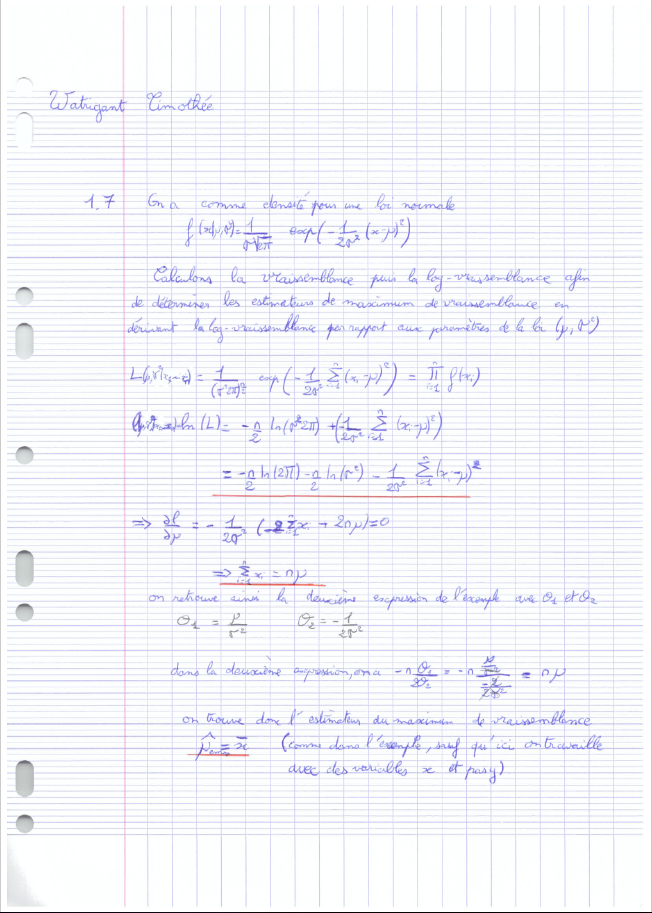

Exercice 1.7(1)

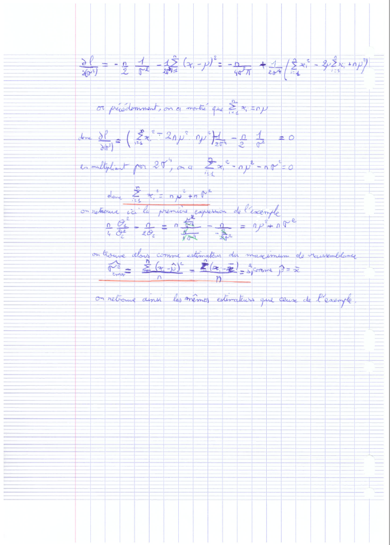

Exercice 1.7(2)

# Exercice 2.1

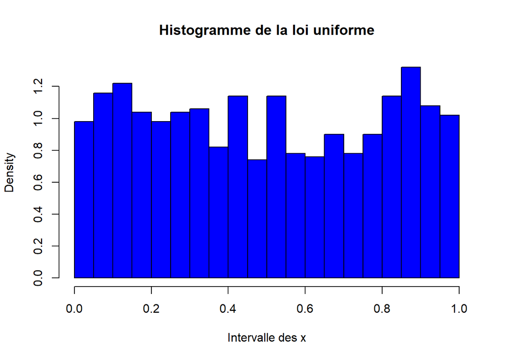

```r
A<-runif(1000)
hist(A,xlab="Intervalle des x",col="blue",main="Histogramme de la loi uniforme",freq=FALSE,breaks=20)
```

On a bien une loi uniforme avec une densité qui reste proche de 1 sur l’ensemble des échantillons malgré le fait que certains événements apparaissent un peu moins souvent que la moyenne (densité<1) et d’autres plus souvent (densité>1). Cette différence de densité est de plus en plus importante lorsque l’on divise encore plus (de plus petit intervalle) pour les x.

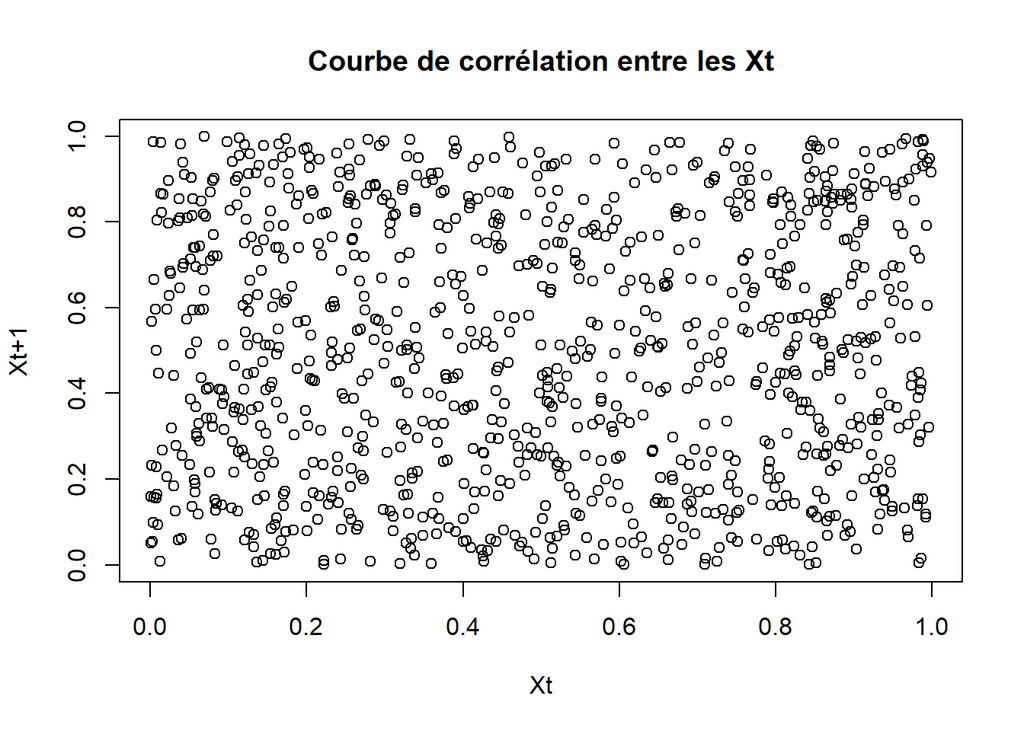

```r
plot(A[1:999],A[2:1000],xlab="Xt",ylab="Xt+1",type="p",main ="Courbe de corrélation entre les Xt")
```

```r
Box.test(A, lag = 1, type = c("Box-Pierce"), fitdf = 0)
```

```
##
##  Box-Pierce test
##
## data:  A
## X-squared = 0.046932, df = 1, p-value = 0.8285
```

```r
Box.test(A, lag = 1, type = c("Ljung-Box"), fitdf = 0)
```

```
##
##  Box-Ljung test
##
## data:  A
## X-squared = 0.047073, df = 1, p-value = 0.8282
```

Il n’y a pas de corrélation entre $X_t$ et $X_{t+1}$ puisqu’il n’y a pas de droite ou de relation explicite qui puisse permettre de lier les points. Cette non-corrélation est vérifiée avec les tests de la Box Pierce et Ljung-Box qui ont des p-values > 10%, donc on peut rejeter l’affirmation que les $X_t$ sont corrélés.

# Exercice 2.2

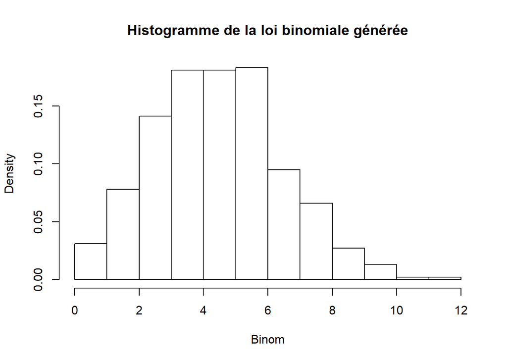

```r
n=25
p=0.2
P<-c()
sk=0
lk=0
k=0
while(lk<0.99999){
  sk[k+1]<-choose(n,k)*p^(k)*(1-p)^(n-k)
  lk<-sk[k+1]+lk
  P[k+1]=lk
  k<-k+1
}

U=runif(1000)


randomgen <- function(u,p){
  k=1
  repeat{
    if(u < p[k])break
      k<-k+1
  }
  return(k-1)
}


Binom <- c()
for(k in 1:length(U)){
  t<-U[k]
  Binom[k]<-randomgen(t,P)
}

hist(Binom,freq=FALSE,main="Histogramme de la loi binomiale générée")
```

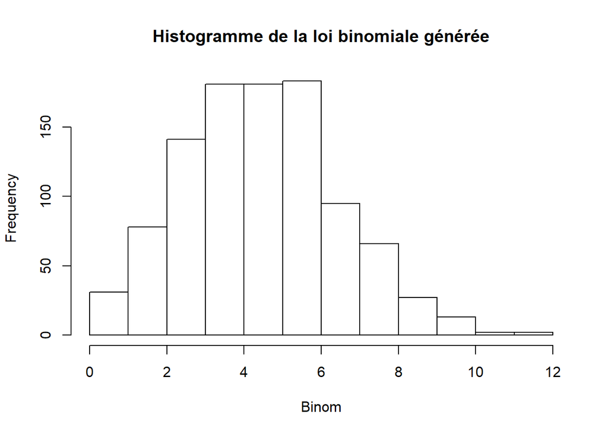

```r
h1<-hist(Binom,main="Histogramme de la loi binomiale générée")
```

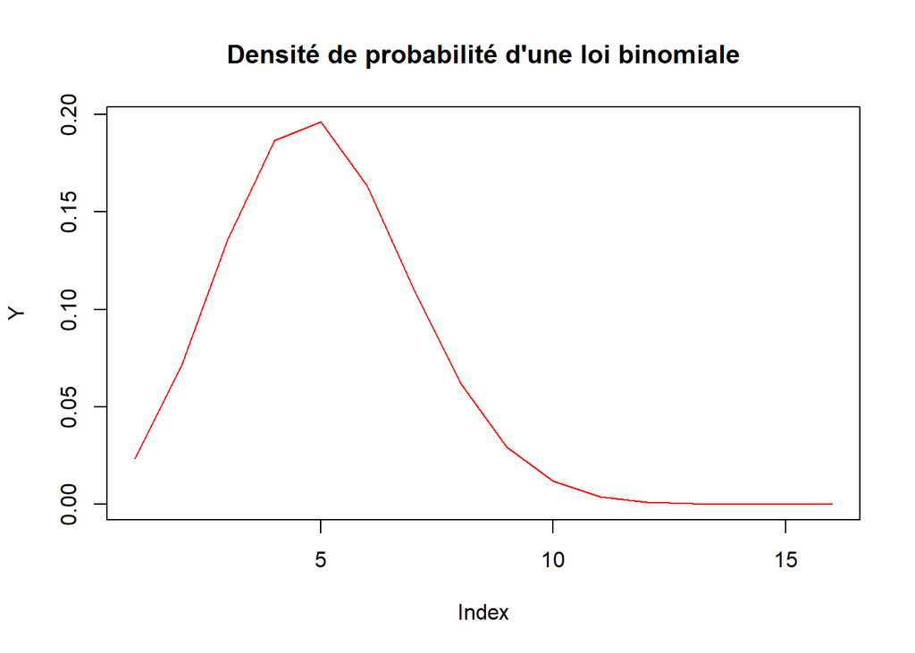

```r
Y<- dbinom(1:length(P),25,0.2)

l1<-plot(Y,type="l",col="red",main="Densité de probabilité d'une loi binomiale")
```

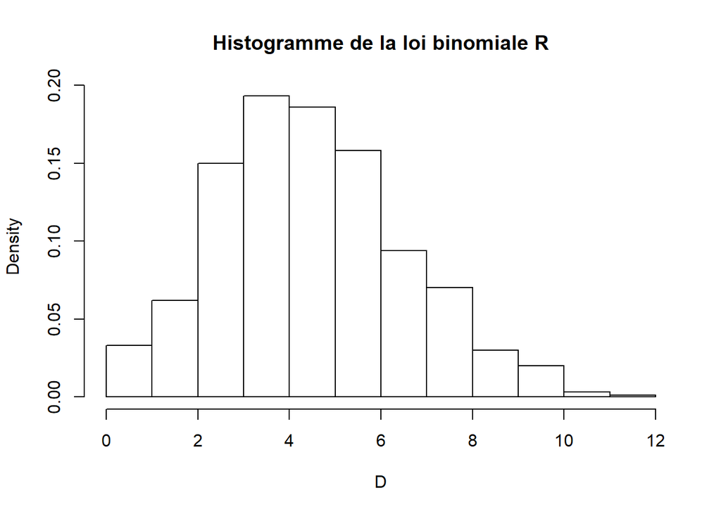

```r
D<-rbinom(1000,25,0.2)

hist(D,freq=FALSE,main="Histogramme de la loi binomiale R")
```

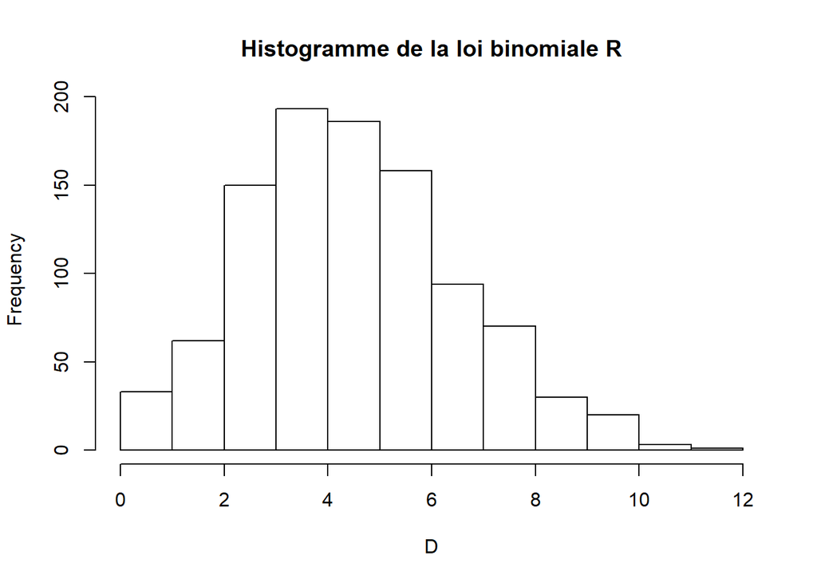

```r
h2<-hist(D,main="Histogramme de la loi binomiale R")
```

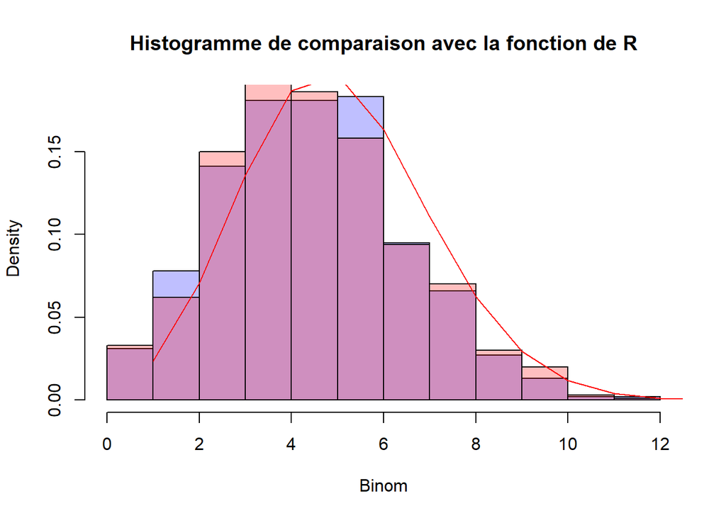

```r
plot( h1,freq=FALSE ,col=rgb(0,0,1,1/4), xlim=c(0,max(Binom)),main="Histogramme de comparaison avec la fonction de R")
plot( h2,freq=FALSE ,col=rgb(1,0,0,1/4), xlim=c(0,max(Binom)), add=T)
lines(Y,col="red",type="l")
```

On voit que les deux histogrammes des fonctions binomiales sont semblables avec la densité générée par R de la fonction binomiale qui semble suivre les deux fonctions binomiales générées. Quelques différences peuvent être observées selon tirage effectué par les fonctions de R.

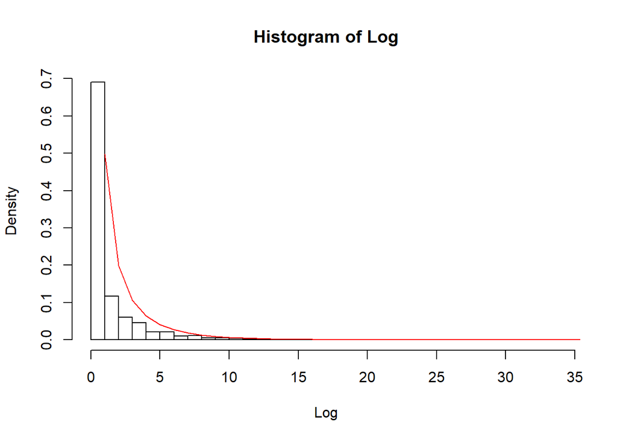

```r
p1<-0.2
P1<-c()
sk1=0
lk1=0
k=1
for(k in 1:5000){
  sk1[k]<- (-(1-p1)^(k))/(k*log(p1))
  lk1<-sk1[k]+lk1
  P1[k]=lk1
  k<-k+1
}

U1=runif(5000)


Log <- c()
for(k in 1:length(U1)){
  t1<-U1[k]
  Log[k]<-randomgen(t1,P1)
}

hist(Log,freq=FALSE,breaks=40)
lines(sk1,type="l",col="red")
```

Comme précédemment, on retrouve que la fonction de densité de la fonction logarithme suit globalement l’allure de l’histogramme de la série de variables aléatoires de la fonction logarithmique même si on voit que la décroissance de la densité est plus lente que celle de la série de variables aléatoires et que sa première valeur est plus faible.